# **Global Country Cross-Analysis**

Visulization Project

Siddhesh Maheshwari

2023-09-29

We have a comprehensive dataset provides a wealth of information about all countries worldwide. It can facilitate in-depth analysis and foster cross-country comparisons. It may serves as a valuable tool for researchers and analysts seeking deeper insights into global trends and international dynamics.

This extensive dataset offers an abundance of data on countries across the globe. It encompasses demographic statistics, economic metrics, environmental factors, healthcare indicators, educational statistics, and a host of other information. With representation from every country, this dataset provides a comprehensive global view of various facets of nations, facilitating in-depth examinations and cross-national assessments. From the Global Country Information Dataset 2023, we’ll focus on the most valuable data for our research needs,even though it offers a wide range of information.

While our dataset encompasses 35 different features, our primary attention will be directed towards specific key indicators. But GDP, Birth Rate, Agricultural Land (%), CO2 Emissions, CPI (Consumer Price Index), Life Expectancy, Unemployment Rate, Population, Tax Revenue, and more.

```r
data=read.csv("/home/sidd/sidd/Visualization_/db/World-data-2023.csv")
library(ggplot2)
```

Name of Features of Data Set

| Density_P_Km2_ | Abbreviation |
| --- | --- |
| Agricultural_Land_ | Land_Area_Km2_ |
| Armed_Forces_size | Birth_Rate |
| Calling_Code | Capital_Major_City |
| Co2_Emissions | CPI |
| CPI_Change_ | Currency_Code |
| Fertility_Rate | Forested_Area_ |
| Gasoline_Price | GDP |
| Gross_primary_education_enrollment_ | Gross_tertiary_education_enrollment_ |
| Infant_mortality | Largest_city |
| Life_expectancy | Maternal_mortality_ratio |
| Minimum_wage | Official_language |
| Out_of_pocket_health_expenditure | Physicians_per_thousand |
| Population | Population_Labor_force_participation_ |
| Tax_revenue_ | Total_tax_rate |
| Unemployment_rate | Urban_population |
| Latitude | Longitude |

Gross Domestic Product, the total value of goods and services produced in the country. Consumer Price Index, a measure of inflation and purchasing power and changes in the cost of living.  
Number of deaths per 1,000 live births before reaching one year of age.  
Tax revenue as a percentage of GDP measures the amount of government revenue collected from taxes relative to the size of the economy (GDP).  
Percentage of the labor force that is unemployed.  
Carbon dioxide (CO2) emissions refer to the release of carbon dioxide gas into the atmospher,.  
The fertility rate represents the average number of children born to a woman over her lifetime.  
It refers to the average number of years a person can expect to live, based on current mortality rates and other demographic factors.

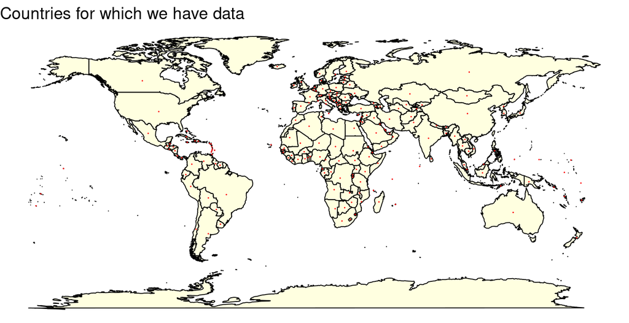

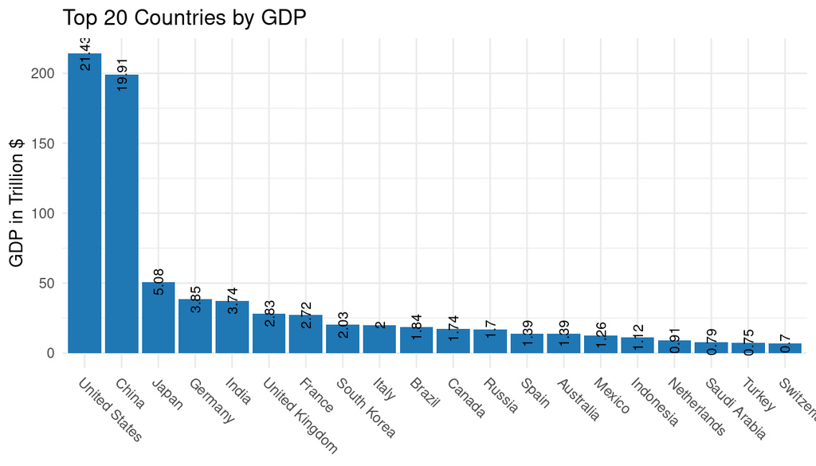

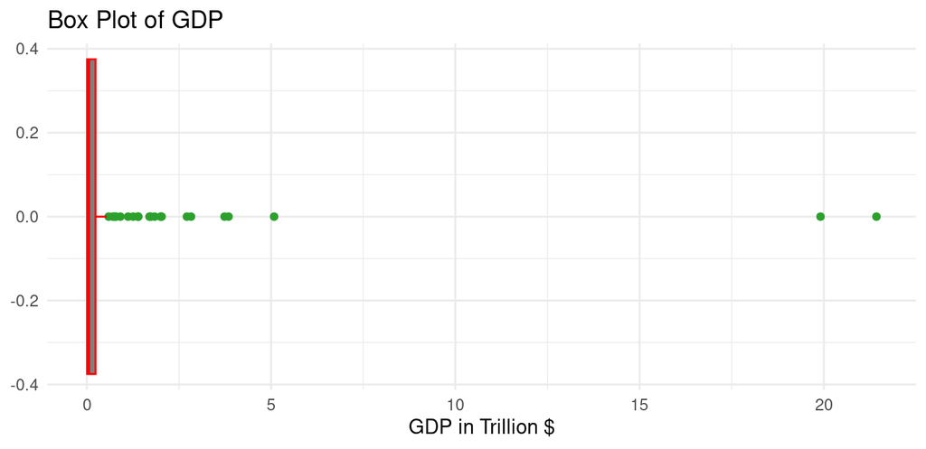

Here We can Clearly See that GDP is highly affected from outliers like United States and China. If we remove some data then make a plot lets see what happens.

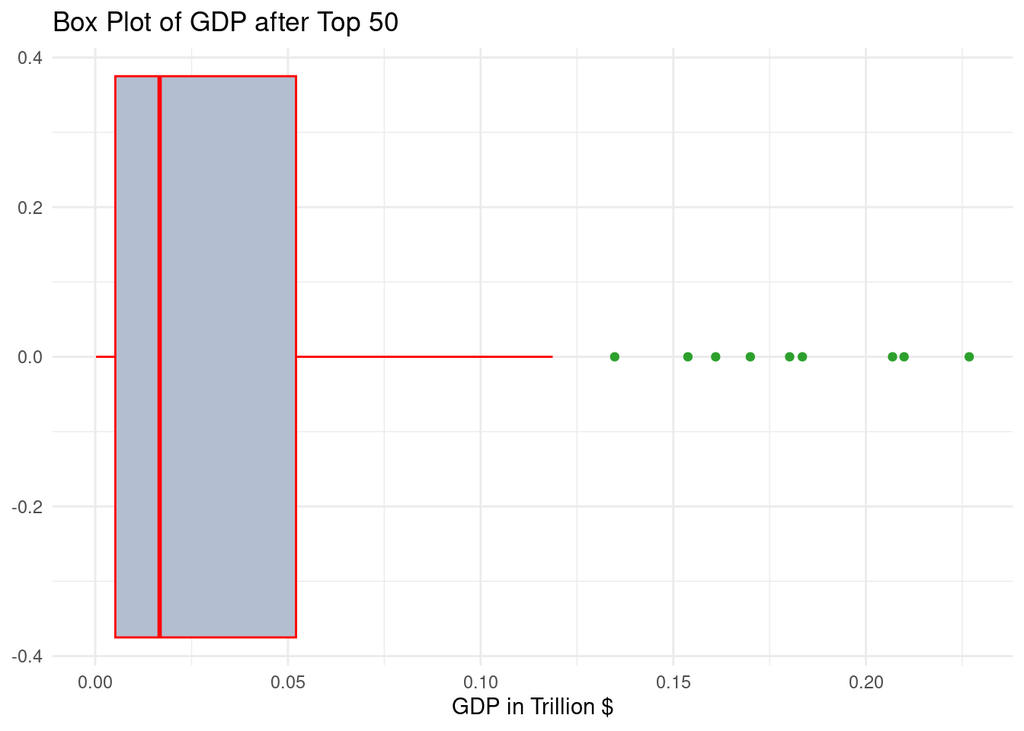

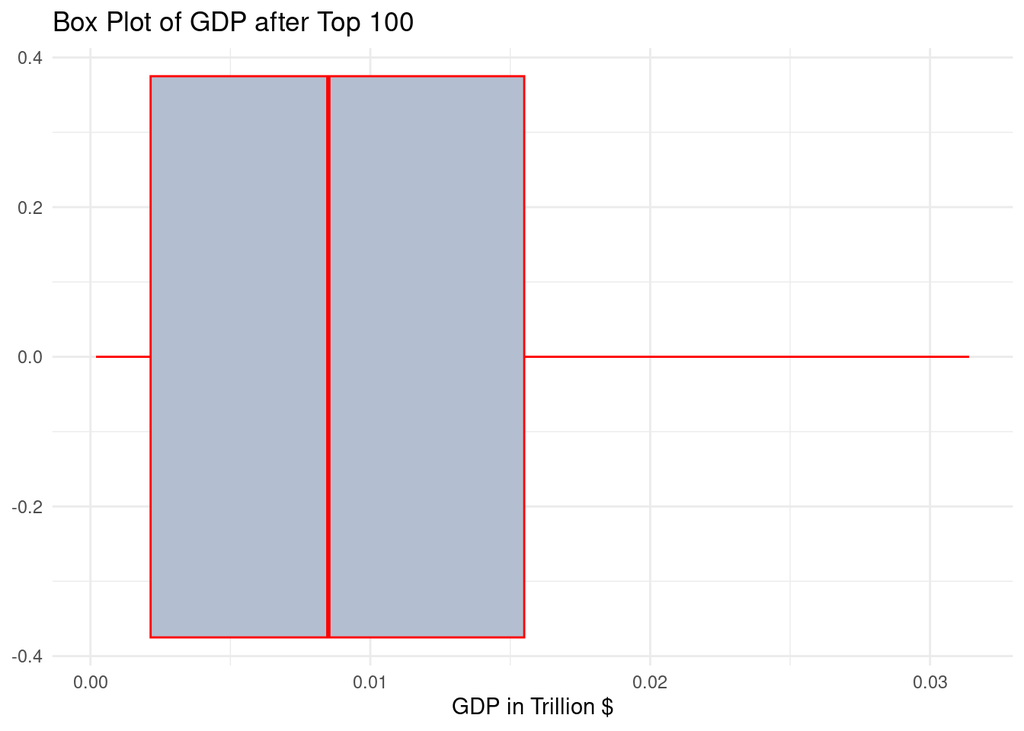

BirthRate : is a demographic measure that quantifies the number of live births in a given population during a specific period (typically per 1,000 people) within that population.

```
[1] "Total Population :  7690485345  # May be some missing Countries"
```

```
[1] "Avarage Birth Rate is :  20.1547340425532"
```

```
[1] "So we can predict That on the given population  154999687  will increase in a year "
```

```
[1] "It will be increased more that 0.15 biilon next year!"
```

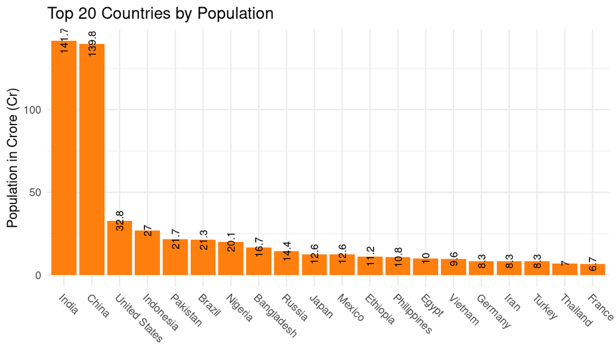

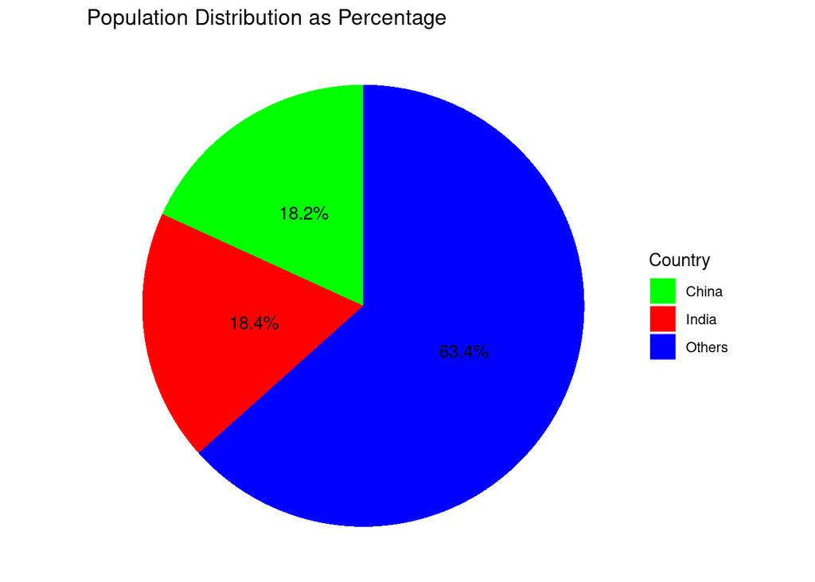

Upon analyzing the plot, it becomes apparent that India faces a challenge in achieving a harmonious equilibrium between GDP and its large population, whereas the United States seems to have effectively managed this balance.

India’s population can be a valuable asset, but it also requires careful management and planning to ensure a high quality of life for its citizens and sustainable development for the country as a whole.

Gross Domestic Product (GDP) per person, a measure of the average income or economic output per individual in a population.

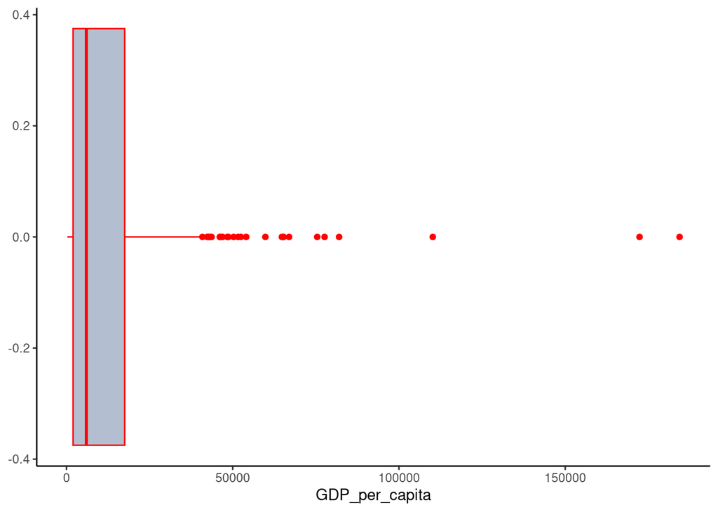

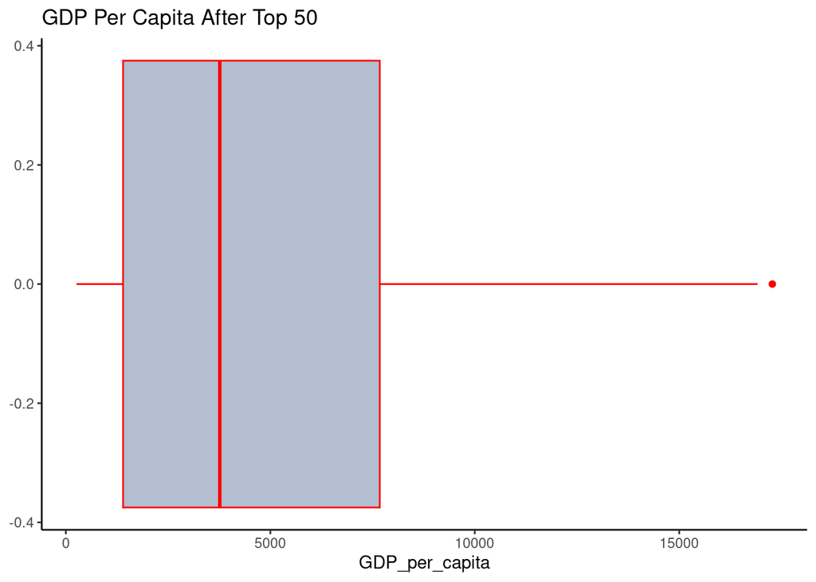

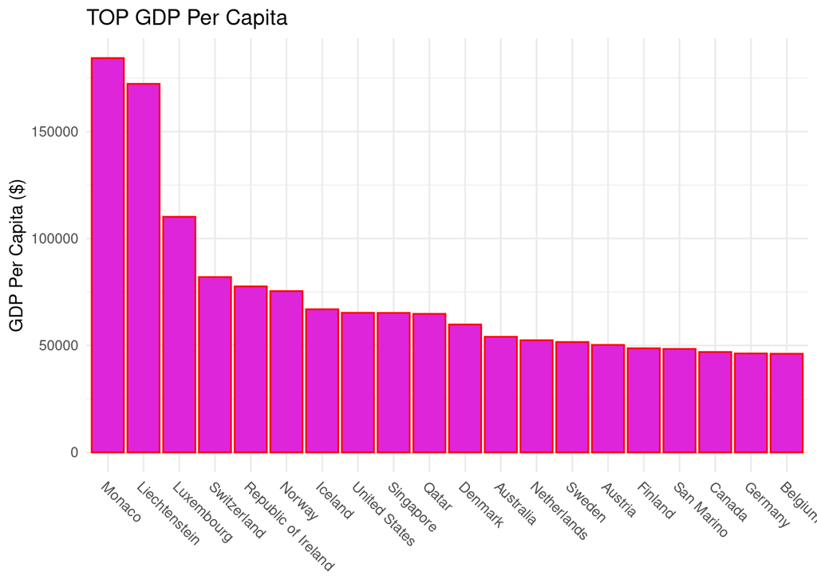

It appears that the GDP per capita is influenced by outliers, but beyond a certain point (among the top countries), there is a more even distribution.

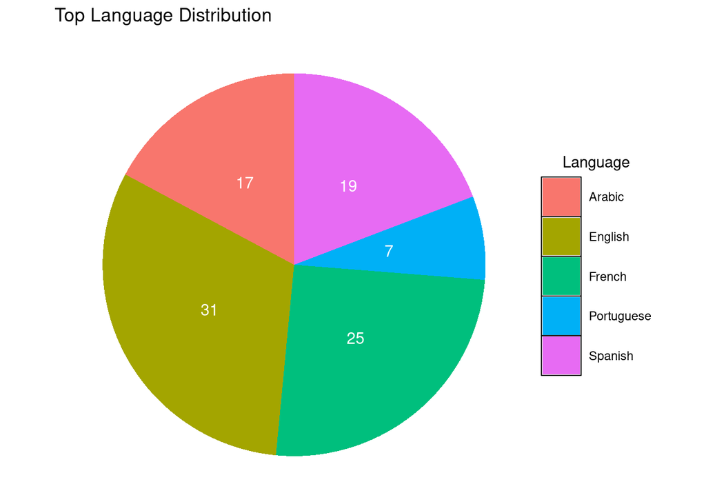

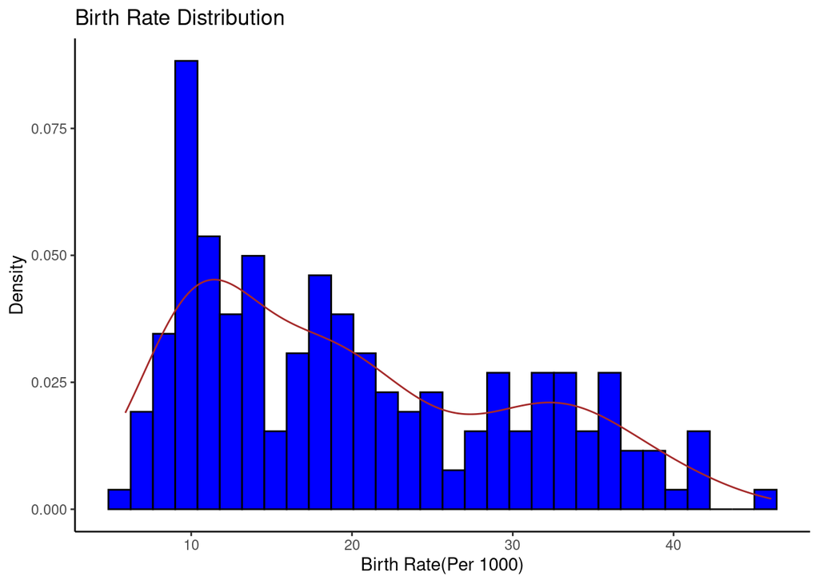

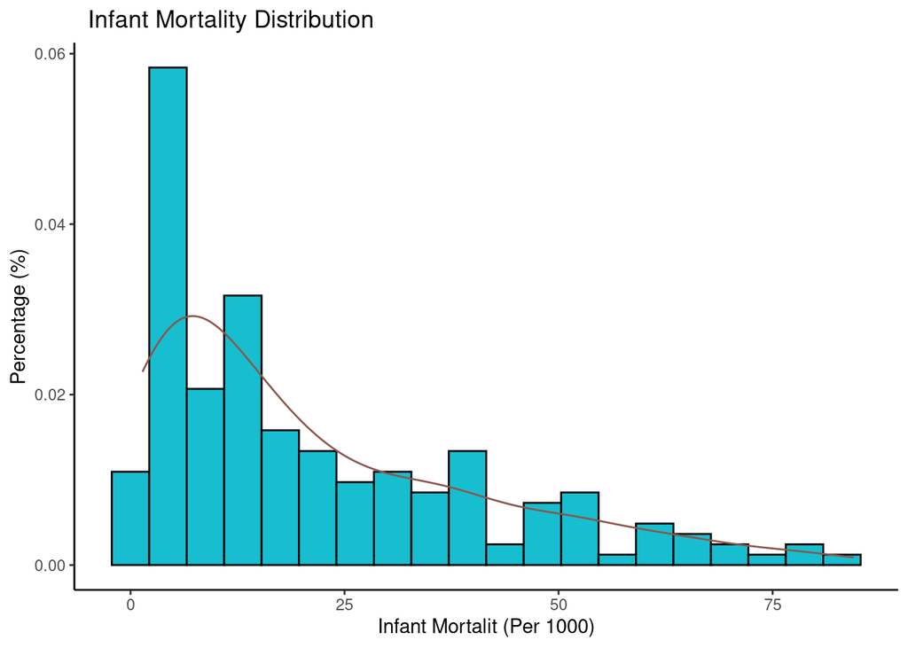

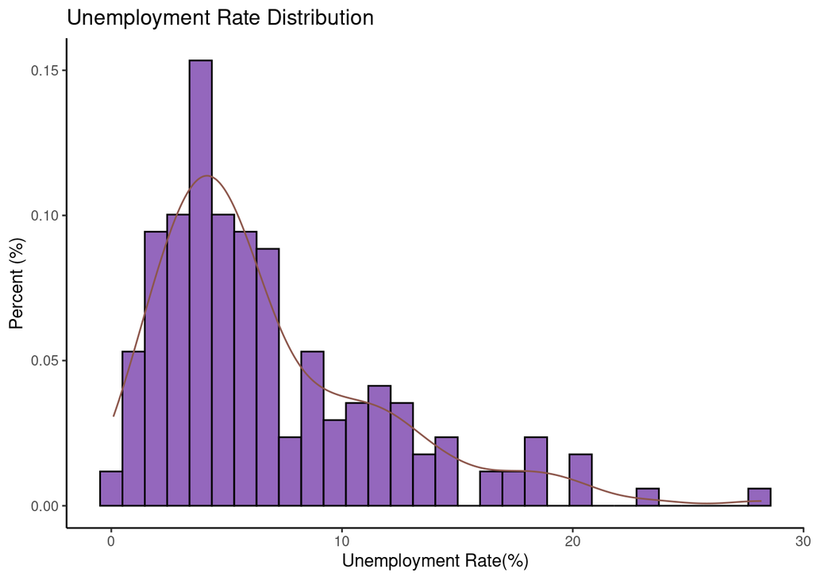

Correlation Matrix

|  | Po. | GDP | Un_Rt | Bir_Rt | Co2_Emi | Fer_Rt | Life_Ex | Infnt_Mor |
| --- | --- | --- | --- | --- | --- | --- | --- | --- |
| Population | 1.00 | 0.60 | -0.02 | 0.11 | 0.78 | 0.09 | -0.27 | 0.25 |
| GDP | 0.60 | 1.00 | 0.11 | -0.17 | 0.91 | -0.13 | 0.07 | -0.10 |
| Unemployment_rate | -0.02 | 0.11 | 1.00 | 0.26 | 0.05 | 0.21 | -0.30 | 0.20 |
| Birth_Rate | 0.11 | -0.17 | 0.26 | 1.00 | -0.10 | 0.97 | -0.84 | 0.85 |
| Co2_Emissions | 0.78 | 0.91 | 0.05 | -0.10 | 1.00 | -0.08 | -0.05 | -0.03 |
| Fertility_Rate | 0.09 | -0.13 | 0.21 | 0.97 | -0.08 | 1.00 | -0.79 | 0.84 |
| Life_expectancy | -0.27 | 0.07 | -0.30 | -0.84 | -0.05 | -0.79 | 1.00 | -0.90 |
| Infant_mortality | 0.25 | -0.10 | 0.20 | 0.85 | -0.03 | 0.84 | -0.90 | 1.00 |

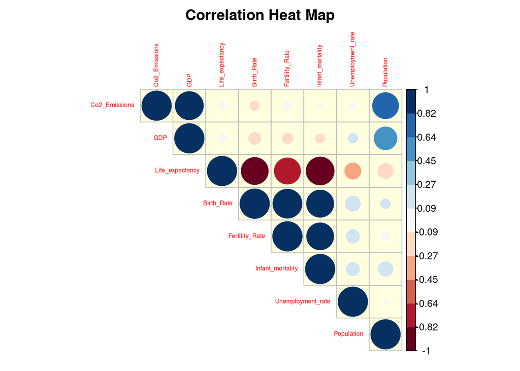

• Unemployment rates does not exhibit a strong correlation with any specific element or factor.  
• Life expectancy is a key factor that demonstrates a strong correlation with various other features or indicators.

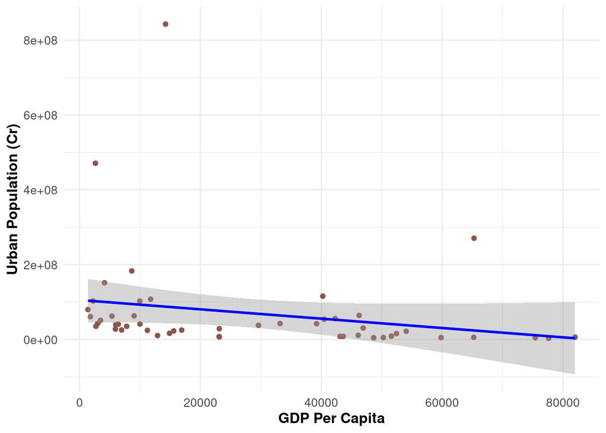

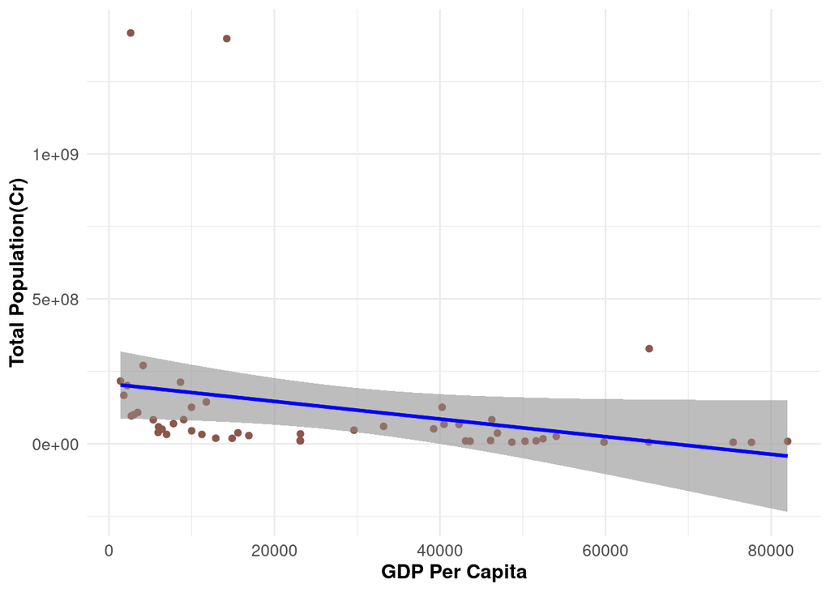

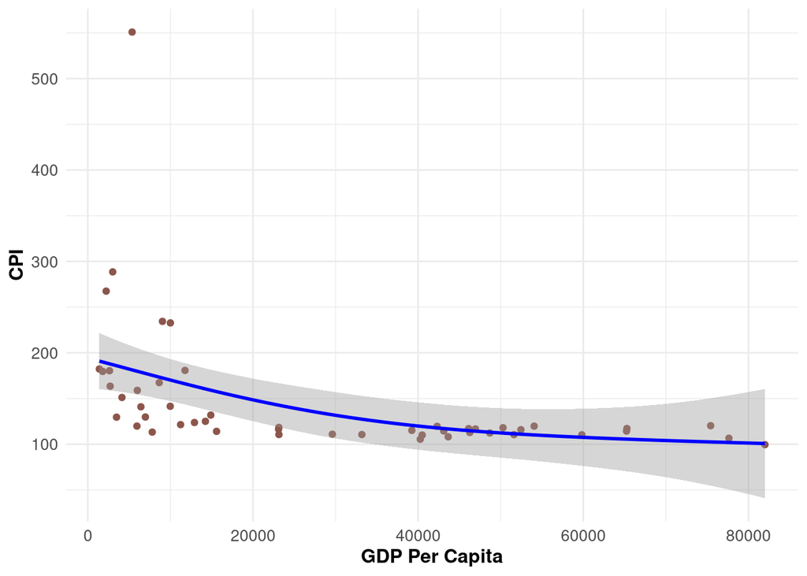

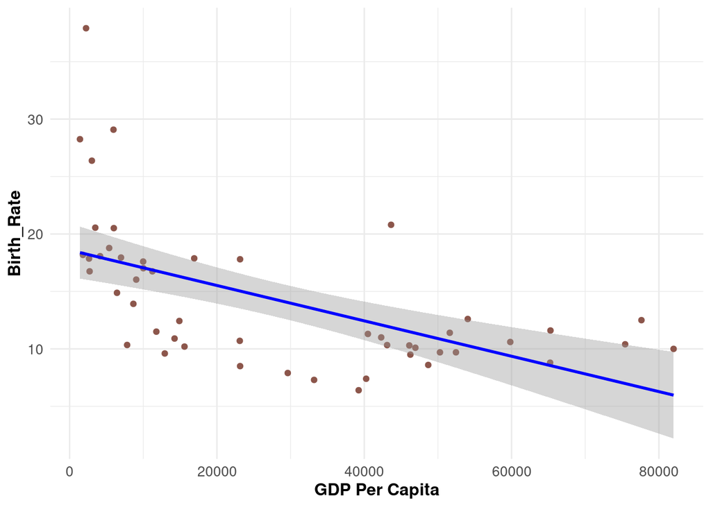

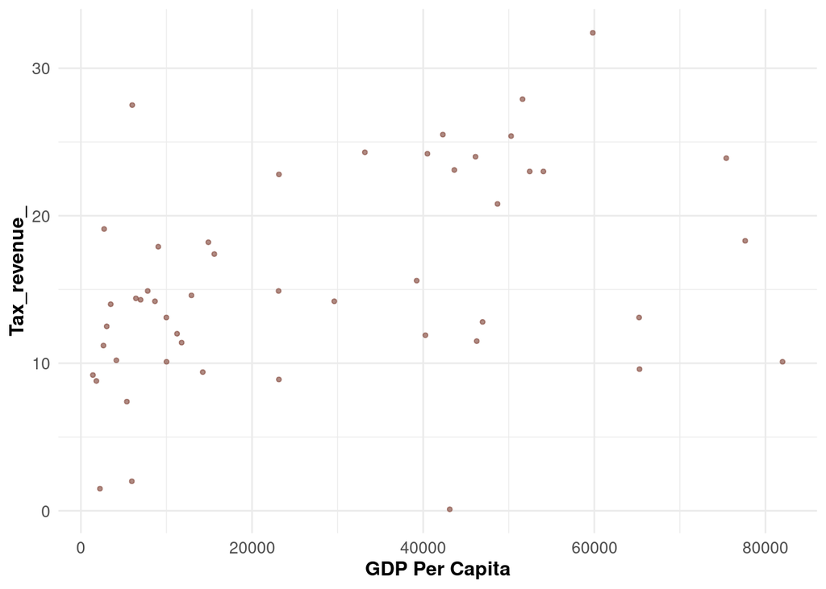

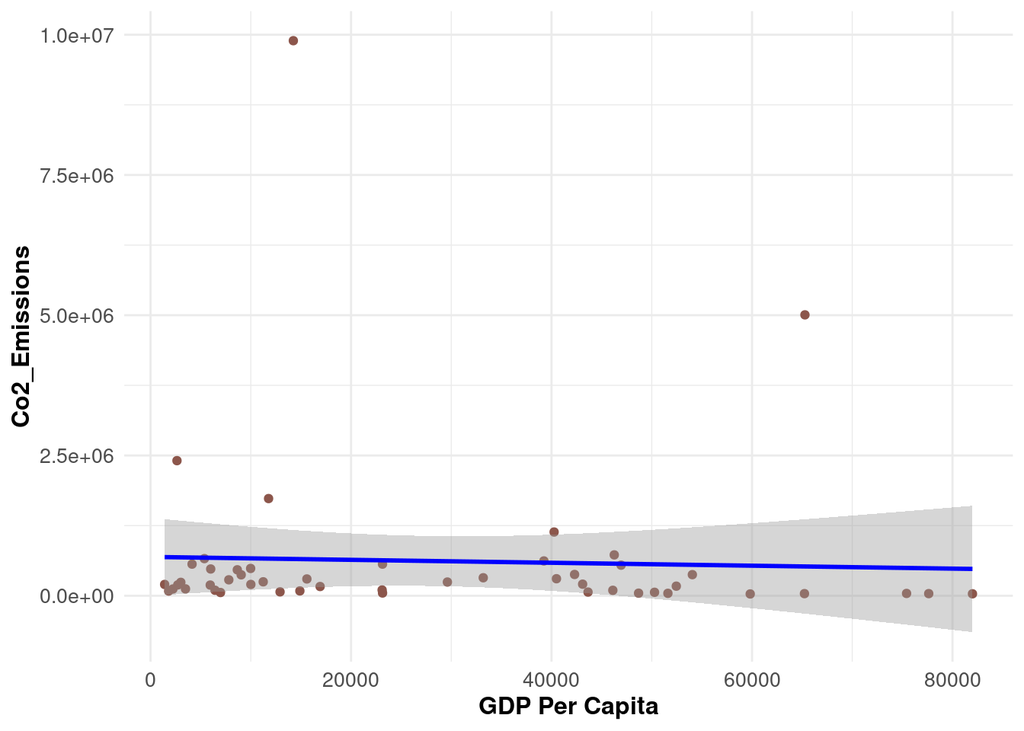

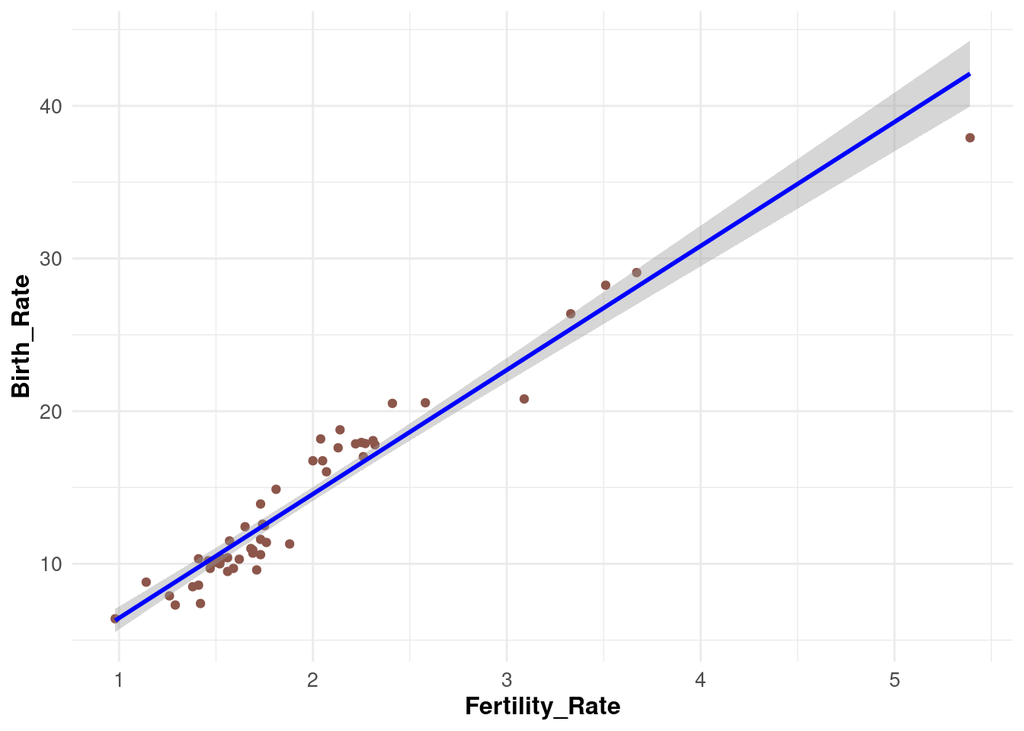

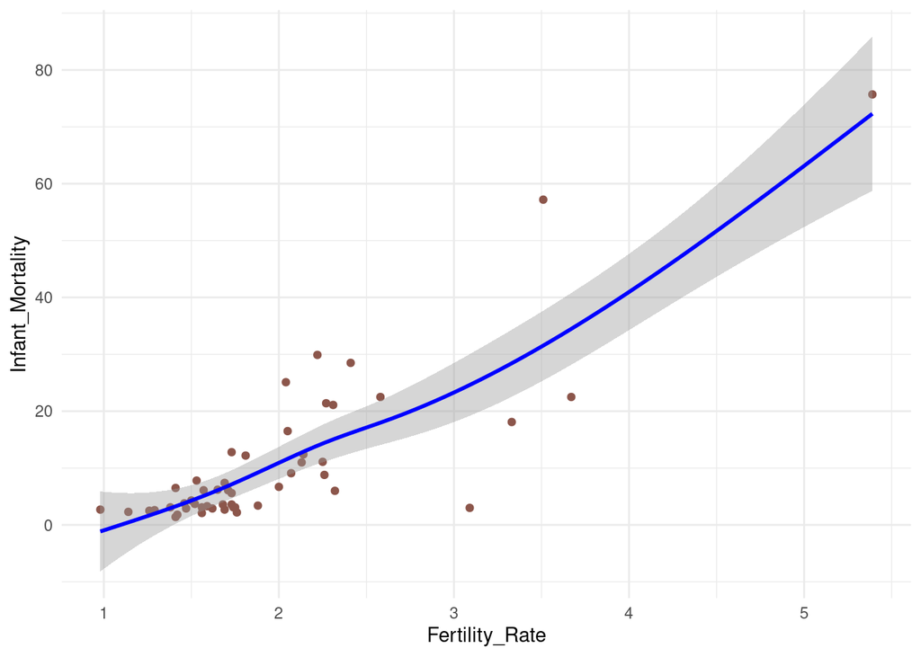

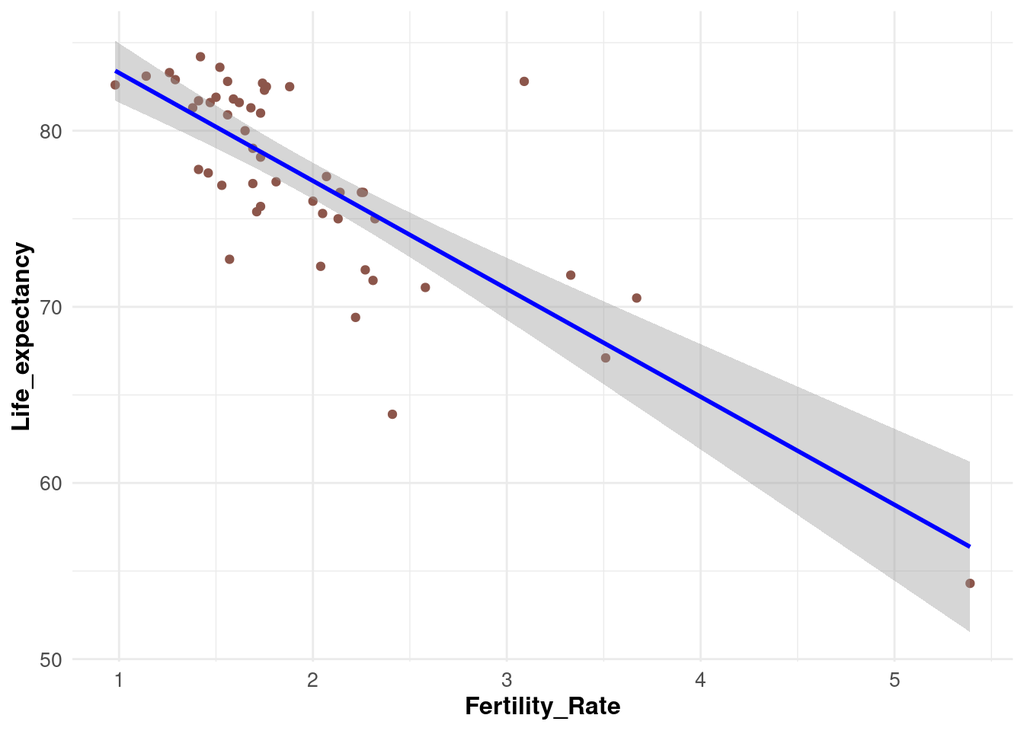

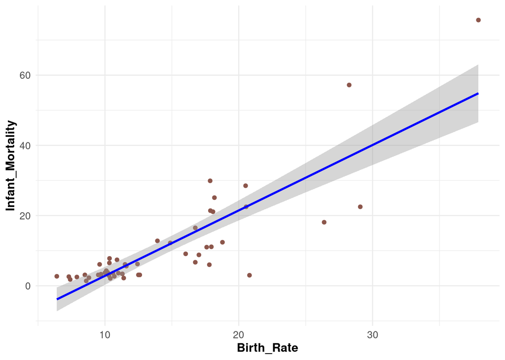

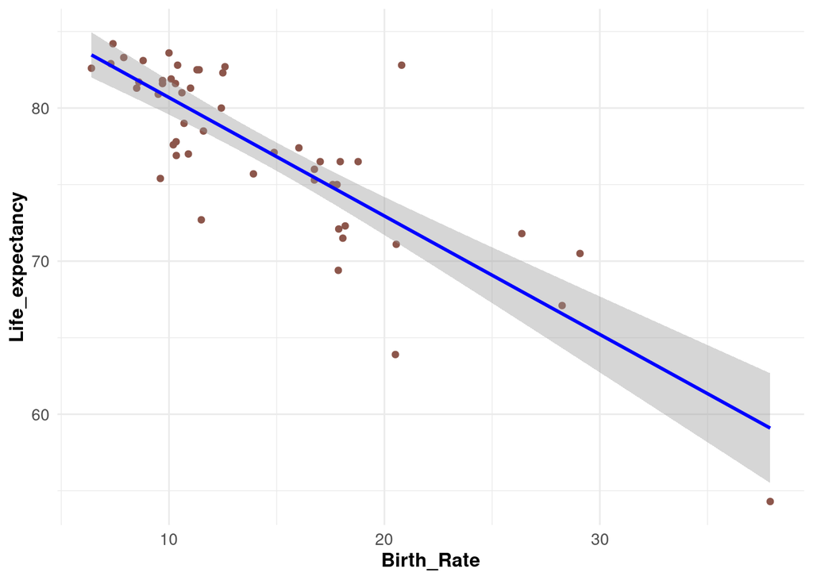

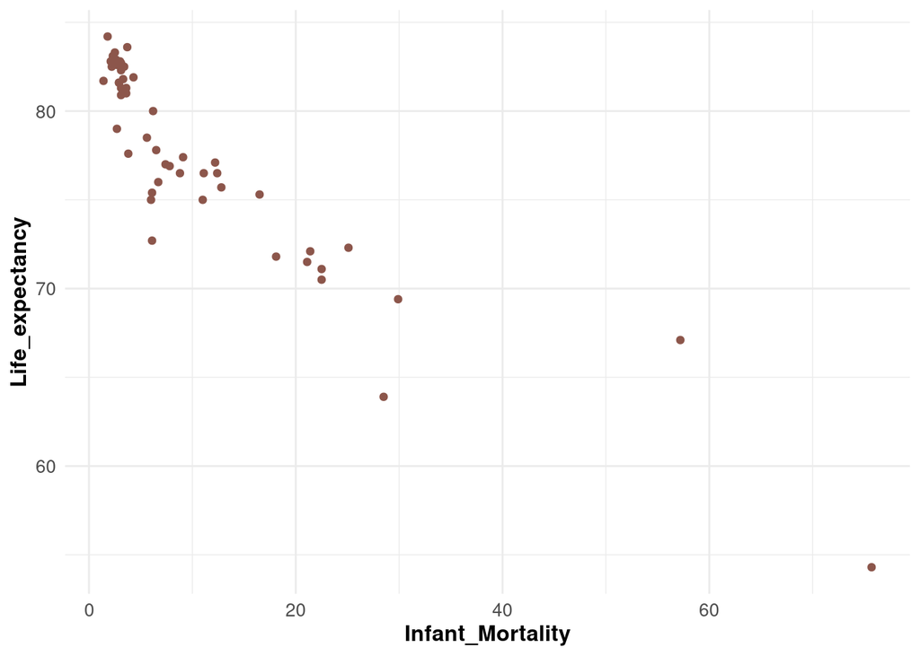

•The scatter plots with linear fitting clearly demonstrate a positive correlation between Fertility Rate, Infant Mortality, and Birth Rate. This means that as one of these variables increases, the others also tend to increase, indicating a strong association among these key demographic factors  
•Whereas Life expectancy is inversely proportional to Fertility Rate, Infant Mortality, and Birth Rate, meaning that as any of these factors increase, life expectancy tends to decreas.

In conclusion, this report offers valuable insights into the complex interplay of economic, demographic, and social factors on a global scale. It highlights the dominance of a few countries in shaping the world economy, the challenges posed by large populations, and the significance of healthcare and family planning in improving overall well-being. Researchers and analysts can leverage these findings to better understand and address global trends and dynamics.